# Practical_Machine_Learning

Supharerk Thawillarp

28 February 2016

## Background

Using devices such as Jawbone Up, Nike FuelBand, and Fitbit it is now possible to collect a large amount of data about personal activity relatively inexpensively. These type of devices are part of the quantified self movement – a group of enthusiasts who take measurements about themselves regularly to improve their health, to find patterns in their behavior, or because they are tech geeks. One thing that people regularly do is quantify how much of a particular activity they do, but they rarely quantify how well they do it. In this project, your goal will be to use data from accelerometers on the belt, forearm, arm, and dumbell of 6 participants. They were asked to perform barbell lifts correctly and incorrectly in 5 different ways. More information is available from the website here: http://groupware.les.inf.puc-rio.br/har (see the section on the Weight Lifting Exercise Dataset).

## Data preparation

First, lets load needed library for this assignment. Training and testing data were loaded with NA replacemnet for null data.

```r
#Load require package
library(caret)
library(rattle)
library(rpart)
```

```r
#Load data
train_data_org<-read.csv("pml-training.csv",na.strings=c("NA",""))
test_data_org<-read.csv("pml-testing.csv",na.strings=c("NA",""))
```

The training set contains 19622 rows and 160 features while the testing data set contains 20 rows and 160 features.

### Data cleaning

After exploring some features, the first 7 features were excluded due to its irrelevant to outcome. Data frame columns containing NA were removed as well.

```r
train_data_org<-train_data_org[,8:length(train_data_org)]
train_data_org<-train_data_org[,sapply(train_data_org,function(x) !any(is.na(x)))]
```

We split training data in to train and validation set with 70% goes to training data.

```r
trainIndex<-createDataPartition(train_data_org$classe,p=0.7,list=F)
train_data<-train_data_org[trainIndex,]
valid_data<-train_data_org[-trainIndex,]
```

## Modeling

### Cross validation

To save some computation time, I’m going to use cross validation. I use the default k=10 argument

```r
control<-trainControl(method="cv",number=10)
```

### Decision Tree

Let’s start with a basic decision tree.

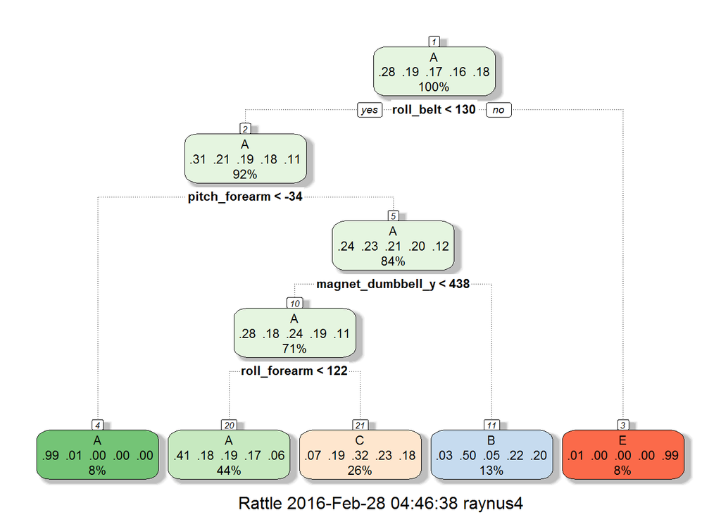

```r
dc_tree<-train(classe~.,data=train_data,method="rpart",trControl=control)
fancyRpartPlot(dc_tree$finalModel)
```

```r
dc_tree
```

```
## CART
##
## 13737 samples
##    52 predictor
##     5 classes: 'A', 'B', 'C', 'D', 'E'
##
## No pre-processing
## Resampling: Cross-Validated (10 fold)
## Summary of sample sizes: 12364, 12362, 12364, 12363, 12363, 12364, ...
## Resampling results across tuning parameters:
##
##   cp          Accuracy   Kappa       Accuracy SD  Kappa SD
##   0.03387244  0.5060091  0.35455691  0.01692623   0.02282092
##   0.05920049  0.4259972  0.22588128  0.06376422   0.10789784
##   0.11534940  0.3231440  0.05910193  0.04117693   0.06245633
##
## Accuracy was used to select the optimal model using  the largest value.
## The final value used for the model was cp = 0.03387244.
```

Unfortunately the accuracy is really bad (0.5), we should go with other model.

```r
confusionMatrix(predict(dc_tree,valid_data),valid_data$classe)
```

```
## Confusion Matrix and Statistics
##
##           Reference
## Prediction    A    B    C    D    E
##          A 1503  470  451  420  167
##          B   26  398   28  180  132
##          C  139  271  547  364  294
##          D    0    0    0    0    0
##          E    6    0    0    0  489
##
## Overall Statistics
##
##                Accuracy : 0.4991
##                  95% CI : (0.4862, 0.5119)
##     No Information Rate : 0.2845
##     P-Value [Acc > NIR] : < 2.2e-16
##
##                   Kappa : 0.3461
##  Mcnemar's Test P-Value : NA
##
## Statistics by Class:
##
##                      Class: A Class: B Class: C Class: D Class: E
## Sensitivity            0.8978  0.34943  0.53314   0.0000  0.45194
## Specificity            0.6419  0.92288  0.78020   1.0000  0.99875
## Pos Pred Value         0.4992  0.52094  0.33870      NaN  0.98788
## Neg Pred Value         0.9405  0.85530  0.88782   0.8362  0.88998
## Prevalence             0.2845  0.19354  0.17434   0.1638  0.18386
## Detection Rate         0.2554  0.06763  0.09295   0.0000  0.08309
## Detection Prevalence   0.5116  0.12982  0.27443   0.0000  0.08411
## Balanced Accuracy      0.7699  0.63616  0.65667   0.5000  0.72535
```

### Random Forest

I choose the popular random forest as the second choice.

```r
rf_model<-train(classe~.,data=train_data,method="rf",trControl=control)
rf_model
```

```
## Random Forest
##
## 13737 samples
##    52 predictor
##     5 classes: 'A', 'B', 'C', 'D', 'E'
##
## No pre-processing
## Resampling: Cross-Validated (10 fold)
## Summary of sample sizes: 12363, 12364, 12361, 12363, 12362, 12364, ...
## Resampling results across tuning parameters:
##
##   mtry  Accuracy   Kappa      Accuracy SD  Kappa SD
##    2    0.9929384  0.9910670  0.001883483  0.002383303
##   27    0.9931583  0.9913451  0.002198297  0.002781187
##   52    0.9871876  0.9837929  0.002642864  0.003341437
##
## Accuracy was used to select the optimal model using  the largest value.
## The final value used for the model was mtry = 27.
```

```r
confusionMatrix(predict(rf_model,valid_data),valid_data$classe)
```

```
## Confusion Matrix and Statistics
##
##           Reference
## Prediction    A    B    C    D    E
##          A 1673    9    0    0    0
##          B    0 1127    6    0    1
##          C    1    3 1015   11    0
##          D    0    0    5  952    6
##          E    0    0    0    1 1075
##
## Overall Statistics
##
##                Accuracy : 0.9927
##                  95% CI : (0.9902, 0.9947)
##     No Information Rate : 0.2845
##     P-Value [Acc > NIR] : < 2.2e-16
##
##                   Kappa : 0.9908
##  Mcnemar's Test P-Value : NA
##
## Statistics by Class:
##
##                      Class: A Class: B Class: C Class: D Class: E
## Sensitivity            0.9994   0.9895   0.9893   0.9876   0.9935
## Specificity            0.9979   0.9985   0.9969   0.9978   0.9998
## Pos Pred Value         0.9946   0.9938   0.9854   0.9886   0.9991
## Neg Pred Value         0.9998   0.9975   0.9977   0.9976   0.9985
## Prevalence             0.2845   0.1935   0.1743   0.1638   0.1839
## Detection Rate         0.2843   0.1915   0.1725   0.1618   0.1827
## Detection Prevalence   0.2858   0.1927   0.1750   0.1636   0.1828
## Balanced Accuracy      0.9986   0.9940   0.9931   0.9927   0.9967
```

This model is a lot better. Its accuracy is 0.99, we are going to use this one for prediction.

## Prediction

Lets predict the classe for testing data set

```r
predict(rf_model,test_data_org)
```

```
##  [1] B A B A A E D B A A B C B A E E A B B B
## Levels: A B C D E
```